[figure not shown]

# Tabular data - Bivariate relationships I: Categorical-Categorical

1. Simple Tables
2. Complex Tables
3. Deliverable II (option 1)

We analyze two variables to find out if there might be some kind of association between them. This time, I will use the [data about crime](https://data.seattle.gov/Public-Safety/SPD-Crime-Data-2008-Present/tazs-3rd5/about_data) from the Seattle Open Data portal. The file has been previously prepared and consists of around half a million rows:

```r
rm(list = ls())

# collecting the data
link="https://github.com/DACSS-Visual/tabular_bivar_catcat/raw/main/data/crime.RData"
load(file = url(link))
```

The columns available are:

```r
# seeing the variable names
names(crime)
```

```
##  [1] "Report.Number"               "Occurred.Date"
##  [3] "year"                        "month"
##  [5] "weekday"                     "Occurred.Time"
##  [7] "Occurred.DayTime"            "Reported.Date"
##  [9] "Reported.Time"               "DaysToReport"
## [11] "crimecat"                    "Crime.Subcategory"
## [13] "Primary.Offense.Description" "Precinct"
## [15] "Sector"                      "Beat"
## [17] "Neighborhood"
```

Let’s see what kind of data we have:

```r
# checking data types
str(crime,width = 50,strict.width='cut')
```

```
## 'data.frame':    499698 obs. of  17 variables:
##  $ Report.Number              : chr  "201300002"..
##  $ Occurred.Date              : Date, format:  ...
##  $ year                       : num  2013 2013 2..
##  $ month                      : num  7 7 7 7 7 7..
##  $ weekday                    : Ord.factor w/ 7"..
##  $ Occurred.Time              : num  1930 1917 1..
##  $ Occurred.DayTime           : Ord.factor w/ 4"..
##  $ Reported.Date              : Date, format:  ...
##  $ Reported.Time              : num  1722 2052 3..
##  $ DaysToReport               : num  1 0 1 1 0 0..
##  $ crimecat                   : Factor w/ 20 le"..
##  $ Crime.Subcategory          : Factor w/ 30 le"..
##  $ Primary.Offense.Description: Factor w/ 144 l"..
##  $ Precinct                   : Factor w/ 5 lev"..
##  $ Sector                     : Factor w/ 23 le"..
##  $ Beat                       : Factor w/ 64 le"..
##  $ Neighborhood               : Factor w/ 58 le"..
```

## Simple contingency table

We start building a **contingency table** to understand cat-cat relationships. Let’s select a couple of categorical variables:

```r
# contingency table of counts
# independent variable in the columns
# dependent variable in the rows
(PrecintDaytime=table(crime$Precinc,crime$Occurred.DayTime))
```

```
##
##               day afternoon evening night
##   EAST      15976     20774   17380 19880
##   NORTH     33744     48754   39867 37942
##   SOUTH     17322     22147   16240 15497
##   SOUTHWEST 10595     14221   11169 11034
##   WEST      30366     48931   33766 30925
```

Let’s prepare the marginal percent (per column) from contingency table:

```r
library(magrittr) # for %>%
(PrecDayti_mgCol=prop.table(PrecintDaytime,
                            margin = 2)%>%round(.,3))
```

```
##
##               day afternoon evening night
##   EAST      0.148     0.134   0.147 0.172
##   NORTH     0.312     0.315   0.337 0.329
##   SOUTH     0.160     0.143   0.137 0.134
##   SOUTHWEST 0.098     0.092   0.094 0.096
##   WEST      0.281     0.316   0.285 0.268
```

The previous table shows you how the crimes that occur in a precinct are affected by the time they happen. So you need a plot that allows to highlight those differences across daytime.

A contingency table can not be plotted in GGPLOT unless it is turned into a **data frame in a long format**:

```r
#making a data frame from contingency table
PrecDaytiDF=as.data.frame(PrecintDaytime)
names(PrecDaytiDF)=c("precint","daytime","counts")

#adding marginal shares as percents:
PrecDaytiDF$pctCol=100*as.data.frame(PrecDayti_mgCol)[,3]
```

Then, you have:

```r
# head of data frame representing contingency table and marginals
PrecDaytiDF
```

```
##      precint   daytime counts pctCol
## 1       EAST       day  15976   14.8
## 2      NORTH       day  33744   31.2
## 3      SOUTH       day  17322   16.0
## 4  SOUTHWEST       day  10595    9.8
## 5       WEST       day  30366   28.1
## 6       EAST afternoon  20774   13.4
## 7      NORTH afternoon  48754   31.5
## 8      SOUTH afternoon  22147   14.3
## 9  SOUTHWEST afternoon  14221    9.2
## 10      WEST afternoon  48931   31.6
## 11      EAST   evening  17380   14.7
## 12     NORTH   evening  39867   33.7
## 13     SOUTH   evening  16240   13.7
## 14 SOUTHWEST   evening  11169    9.4
## 15      WEST   evening  33766   28.5
## 16      EAST     night  19880   17.2
## 17     NORTH     night  37942   32.9
## 18     SOUTH     night  15497   13.4
## 19 SOUTHWEST     night  11034    9.6
## 20      WEST     night  30925   26.8
```

First, let’s tell ggplot to show bars of *counts* by *daytime*:

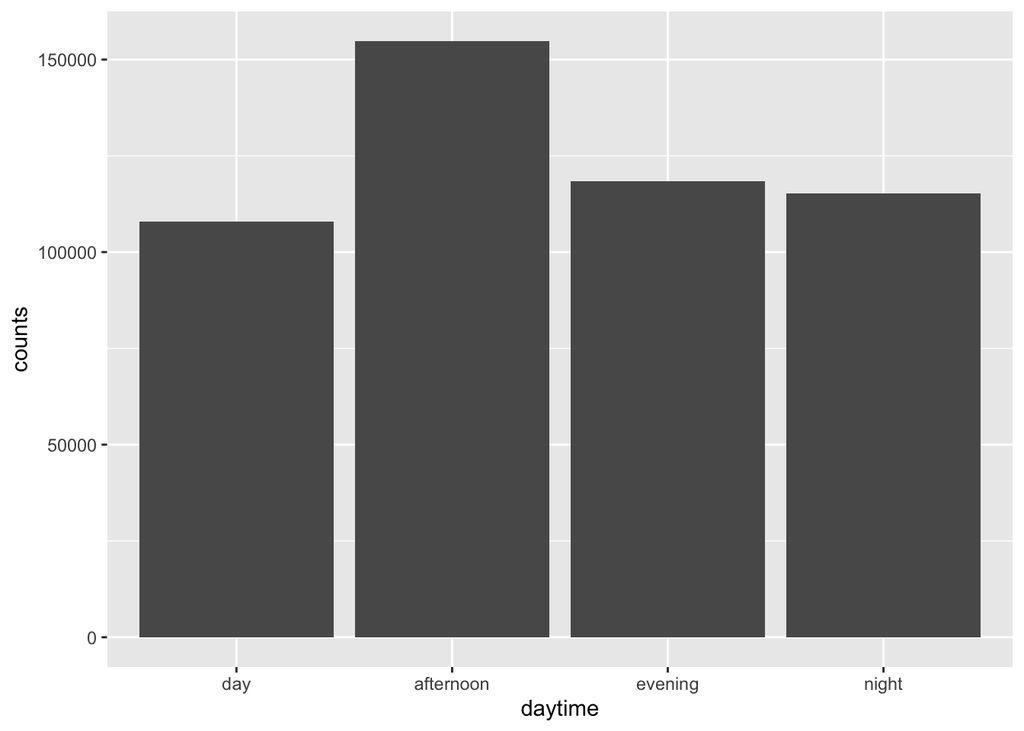

```r
library(ggplot2)
ggplot(data=PrecDaytiDF,
             aes(x=daytime, y=counts)) + geom_bar(stat="identity")
```

Now, include the *color fill* in the aesthetics to color according to precinct using the **dodge** style

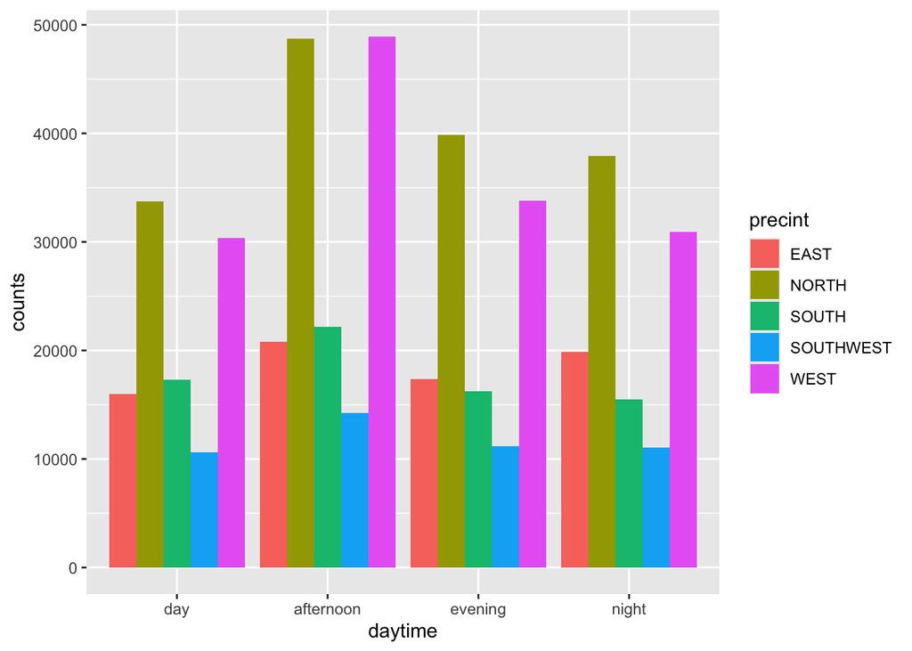

```r
base1=ggplot(data=PrecDaytiDF,
             aes(x=daytime, y=counts,
                 fill=precint)) # fill brings a legend
barDodge1= base1 +  geom_bar(stat="identity",
                            position ='dodge')
barDodge1
```

Remember that the fill is encoding a **nominal** variable, so you can **reorder** them (notice that currently the order is alphabetic). Also, this time I will use the percent instead:

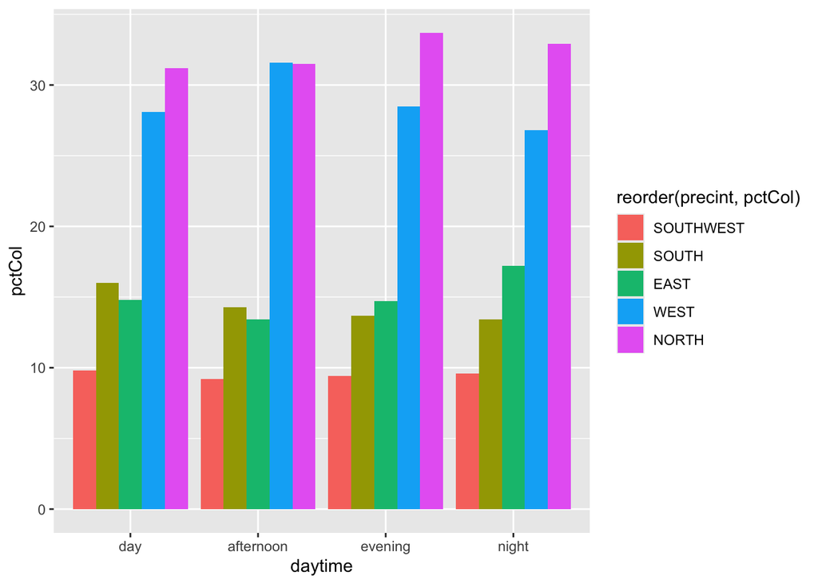

```r
base1_pct=ggplot(data=PrecDaytiDF,
             aes(x=daytime, y=pctCol,
                 fill=reorder(precint,pctCol))) # reordering
barDodge1_pct= base1_pct +  geom_bar(stat="identity",
                            position ='dodge')
barDodge1_pct
```

From there, a next step could be:

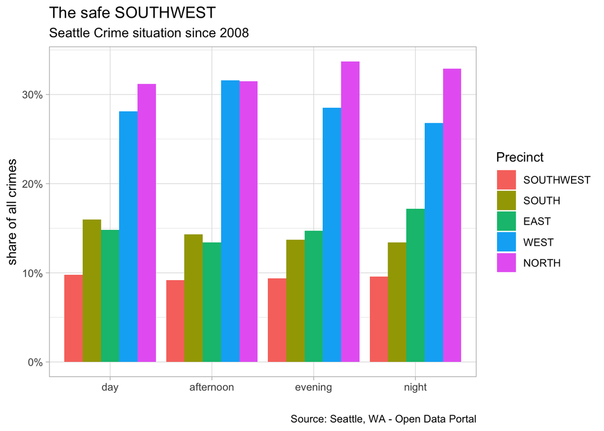

```r
barDodge1_pct + labs(title = "The safe SOUTHWEST",
                 subtitle = "Seattle Crime situation since 2008",
                 x="",
                 y="share of all crimes",
                 fill="Precinct",
                 caption = "Source: Seattle, WA - Open Data Portal") +
            theme_light()    +
            scale_y_continuous(labels=scales::unit_format(suffix = '%'))
```

What about changing variables and background:

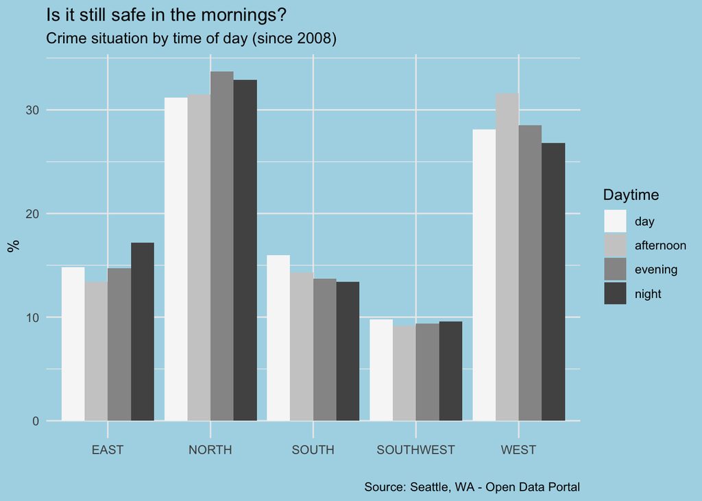

```r
base_bad=ggplot(data=PrecDaytiDF,
             aes(x=precint, y=pctCol, # % not counts
                 fill=daytime)) + theme_minimal()
barDodge2_bad= base_bad +  geom_bar(stat="identity",
                            position ='dodge')
barDodge2_bad + labs(title = "Is it still safe in the mornings?",
                 subtitle = "Crime situation by time of day (since 2008)",
                 x="",
                 y="%",
                 fill="Daytime",
                 caption = "Source: Seattle, WA - Open Data Portal") + scale_fill_brewer(palette = 'Greys') + theme(plot.background = element_rect(fill = "lightblue",
                                colour = "lightblue"))
```

The previous plot is wrong. Why?

Notice the margins (percents) were calculated for the previous cases. The right version follows:

```r
# different variables for rows and columns
DaytimePrecint=table(crime$Occurred.DayTime,crime$Precinc)
DaytimePrecint_mgCol=prop.table(DaytimePrecint,
                            margin = 2)%>%round(.,3)

#Now prepare the data frame as before
DaytimePrecintDF=as.data.frame(DaytimePrecint)
names(DaytimePrecintDF)=c("daytime","precint","counts")
DaytimePrecintDF$pctCol=100*as.data.frame(DaytimePrecint_mgCol)[,3]

#see
DaytimePrecintDF
```

```
##      daytime   precint counts pctCol
## 1        day      EAST  15976   21.6
## 2  afternoon      EAST  20774   28.1
## 3    evening      EAST  17380   23.5
## 4      night      EAST  19880   26.9
## 5        day     NORTH  33744   21.0
## 6  afternoon     NORTH  48754   30.4
## 7    evening     NORTH  39867   24.9
## 8      night     NORTH  37942   23.7
## 9        day     SOUTH  17322   24.3
## 10 afternoon     SOUTH  22147   31.1
## 11   evening     SOUTH  16240   22.8
## 12     night     SOUTH  15497   21.8
## 13       day SOUTHWEST  10595   22.5
## 14 afternoon SOUTHWEST  14221   30.2
## 15   evening SOUTHWEST  11169   23.8
## 16     night SOUTHWEST  11034   23.5
## 17       day      WEST  30366   21.1
## 18 afternoon      WEST  48931   34.0
## 19   evening      WEST  33766   23.5
## 20     night      WEST  30925   21.5
```

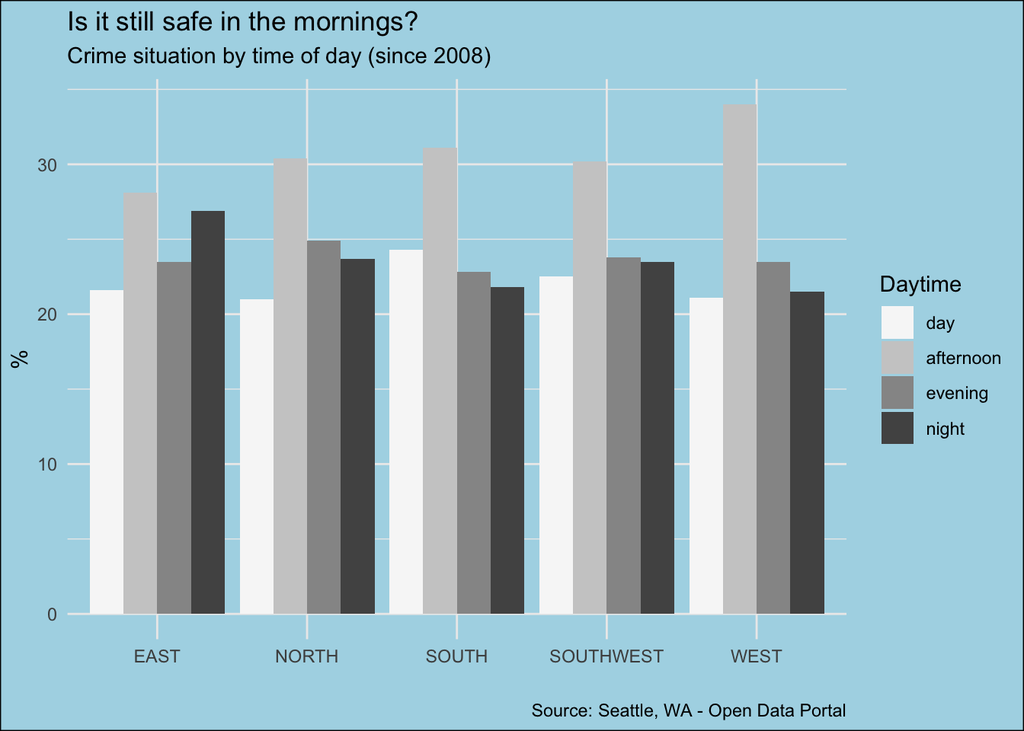

```r
base2_ok=ggplot(data=DaytimePrecintDF,
             aes(x=precint, y=pctCol, # % not counts
                 fill=daytime)) + theme_minimal()
barDodge2_ok= base2_ok +  geom_bar(stat="identity",
                            position ='dodge')
barDodge2_ok + labs(title = "Is it still safe in the mornings?",
                 subtitle = "Crime situation by time of day (since 2008)",
                 x="",
                 y="%",
                 fill="Daytime",
                 caption = "Source: Seattle, WA - Open Data Portal") + scale_fill_brewer(palette = 'Greys') + theme(plot.background = element_rect(fill = "lightblue",
                                colour = "black"))
```

Now, both are helping highlight **within-group** differences.

Let’s see the **stack** style next:

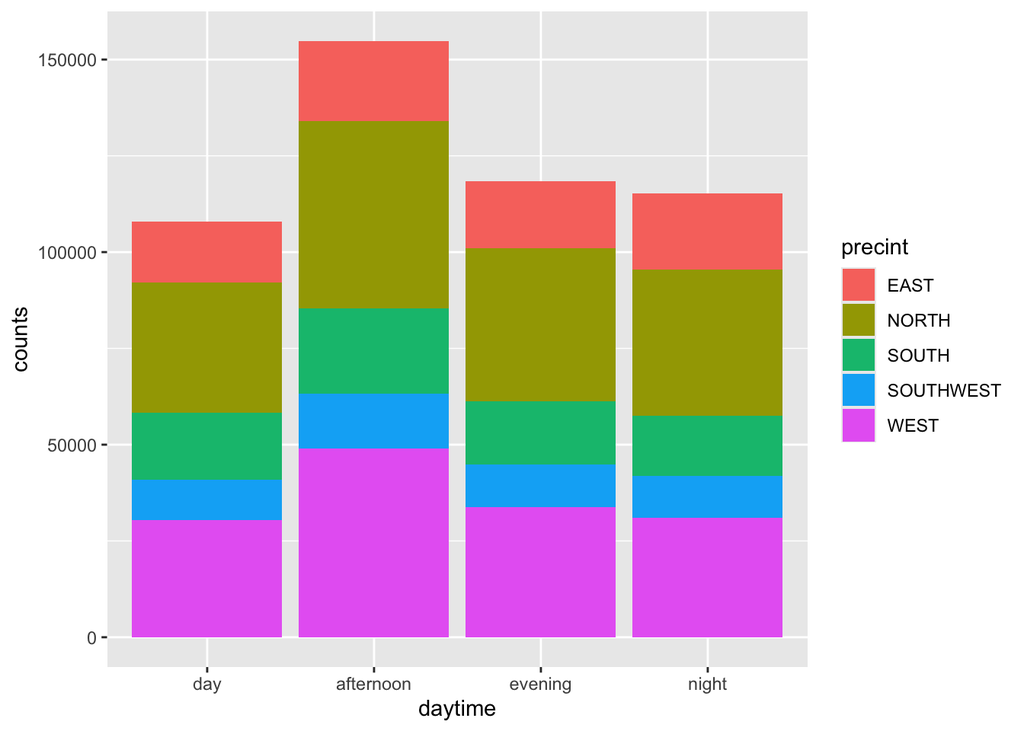

```r
# USING COUNTS
barStacked_counts = base1 + geom_bar(stat = "identity",
                              position = 'stack')#default
barStacked_counts
```

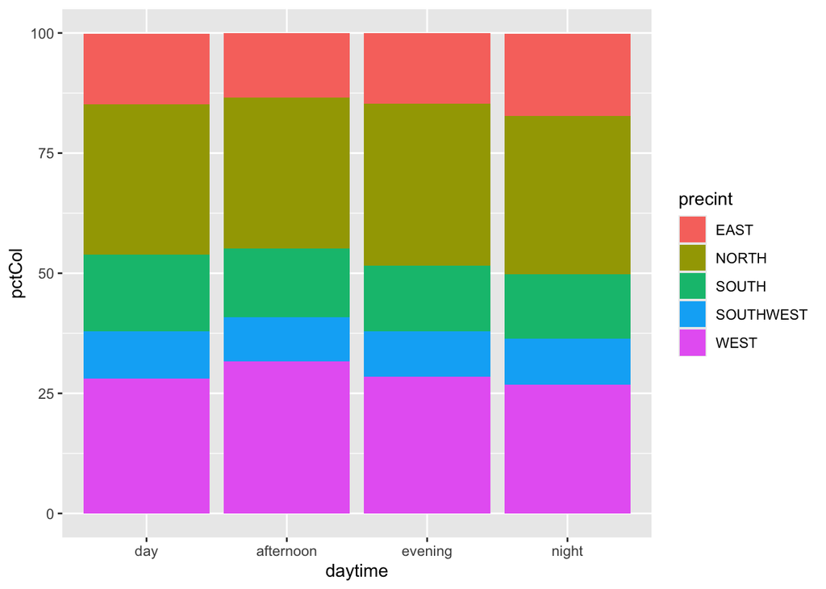

```r
# USING PERCENTS
base1_pct=ggplot(data=PrecDaytiDF,
             aes(x=daytime, y=pctCol,
                 fill=precint))
barStacked_pcts = base1_pct + geom_bar(stat = "identity",
                              position = 'stack')#default
barStacked_pcts
```

The stacked version using counts will help you to highlight *whole-part*, while the one based on percents will *relative-contribution*. The latter looks like the contingency table itself, so let’s continue adding some other elements to that one:

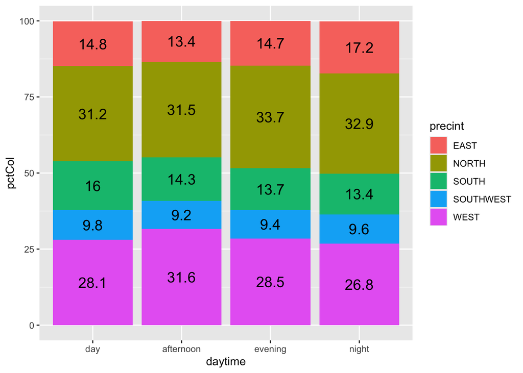

```r
library(scales)
barStacked_pcts= barStacked_pcts + geom_text(size = 5,# check below:
                             position = position_stack(vjust = 0.5),# center
                             aes(label=pctCol))# percent format

barStacked_pcts
```

Since the precinct is nominal, and you see some marked differences along the rows, I can reorder its levels. Let me reorder the percents as we did before, while also changing fill color:

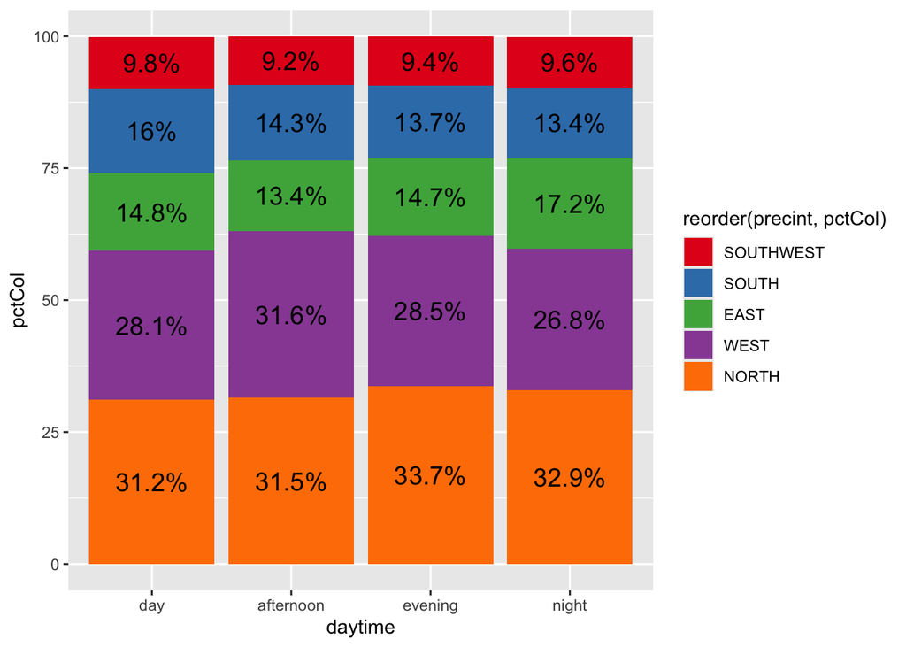

```r
base3=ggplot(data=PrecDaytiDF,
             aes(x=daytime, y=pctCol,
                 fill=reorder(precint,pctCol)))

barStacked_pcts_reordered = base3 + geom_bar(stat = "identity",
                              position = 'stack')
barStacked_pcts_reordered= barStacked_pcts_reordered + geom_text(size = 5,
                             position = position_stack(vjust = 0.5),
                             aes(label=paste0(pctCol,'%')))


barStacked_pcts_reordered=barStacked_pcts_reordered + scale_fill_brewer(palette = 'Set1')
barStacked_pcts_reordered
```

What else should be done? What is missing?

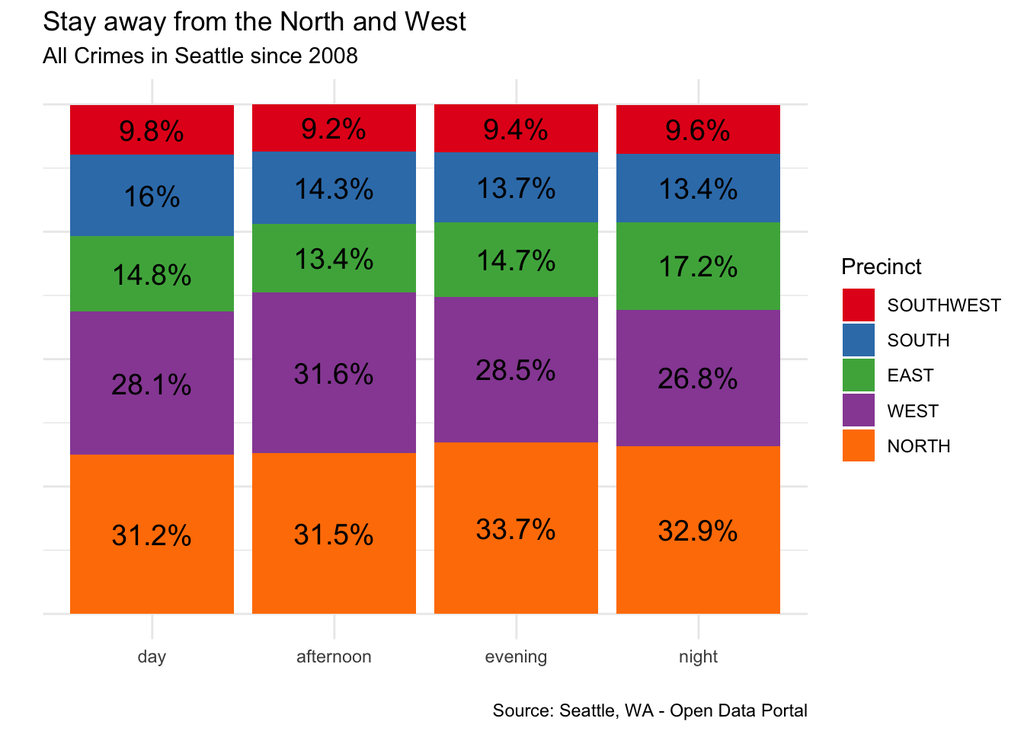

```r
barStacked_pcts_reordered + theme_minimal() +
    labs(title = "Stay away from the North and West",
                 subtitle = "All Crimes in Seattle since 2008",
                 x="",
                 y="",
                 fill='Precinct',
                 caption = "Source: Seattle, WA - Open Data Portal") +
    theme(axis.text.y =element_blank())
```

Go to table of contents.

## Complex contingency table

Let me show you a more complex situation:

```r
# contingency table with many levels:

(CrimeDay=table(crime$crimecat,crime$Occurred.DayTime))
```

```
##
##                               day afternoon evening night
##   AGGRAVATED ASSAULT         3564      5366    4884  7501
##   ARSON                       196       167     191   486
##   BURGLARY                  24139     22288   14121 16082
##   CAR PROWL                 26740     38273   42595 34839
##   DISORDERLY CONDUCT           41        81      67    79
##   DUI                         706       939    2038  8522
##   FAMILY OFFENSE-NONVIOLENT  1748      2516    1217  1120
##   GAMBLE                        4         4       7     2
##   HOMICIDE                     41        46      49   131
##   LIQUOR LAW VIOLATION        112       491     410   606
##   LOITERING                    20        31      25     9
##   NARCOTIC                   2415      6416    3924  4109
##   PORNOGRAPHY                  65        53      17    31
##   PROSTITUTION                115       675    1425  1340
##   RAPE                        332       318     354   854
##   ROBBERY                    2584      4737    4139  5372
##   SEX OFFENSE-OTHER          1501      1759    1014  1776
##   THEFT                     38687     64868   38980 28410
##   TRESPASS                   4848      5184    2598  3289
##   WEAPON                      735      1445     947  1624
```

This contingency table has one categorical variables with several levels, let’s turn the table into a data frame:

```r
#making a data frame from contingency table
CrimeDayDF=as.data.frame(CrimeDay)
#renaming:
names(CrimeDayDF)=c("crime","daytime","counts")
#marginal
CrimeDay_mgCol=100*prop.table(CrimeDay,margin = 2)
#adding marginal
CrimeDayDF$pctCol=round(as.data.frame(CrimeDay_mgCol)[,3],1)
# result for ggplot:
head(CrimeDayDF,20)
```

```
##                        crime daytime counts pctCol
## 1         AGGRAVATED ASSAULT     day   3564    3.3
## 2                      ARSON     day    196    0.2
## 3                   BURGLARY     day  24139   22.2
## 4                  CAR PROWL     day  26740   24.6
## 5         DISORDERLY CONDUCT     day     41    0.0
## 6                        DUI     day    706    0.7
## 7  FAMILY OFFENSE-NONVIOLENT     day   1748    1.6
## 8                     GAMBLE     day      4    0.0
## 9                   HOMICIDE     day     41    0.0
## 10      LIQUOR LAW VIOLATION     day    112    0.1
## 11                 LOITERING     day     20    0.0
## 12                  NARCOTIC     day   2415    2.2
## 13               PORNOGRAPHY     day     65    0.1
## 14              PROSTITUTION     day    115    0.1
## 15                      RAPE     day    332    0.3
## 16                   ROBBERY     day   2584    2.4
## 17         SEX OFFENSE-OTHER     day   1501    1.4
## 18                     THEFT     day  38687   35.6
## 19                  TRESPASS     day   4848    4.5
## 20                    WEAPON     day    735    0.7
```

Last time, we turn the contingency table into a stacked barplot, let’s try again:

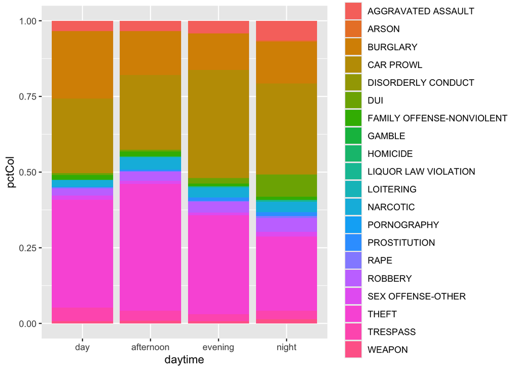

```r
# bad idea
ggplot(data=CrimeDayDF,
             aes(x=daytime,y=pctCol,fill=crime)) +
    geom_bar(stat = "identity", position = 'fill')
```

This plot will need a lot of work, so using the previous plots may not be a good strategy.

A first option you may have is to reproduce the table, let’s try point sizes:

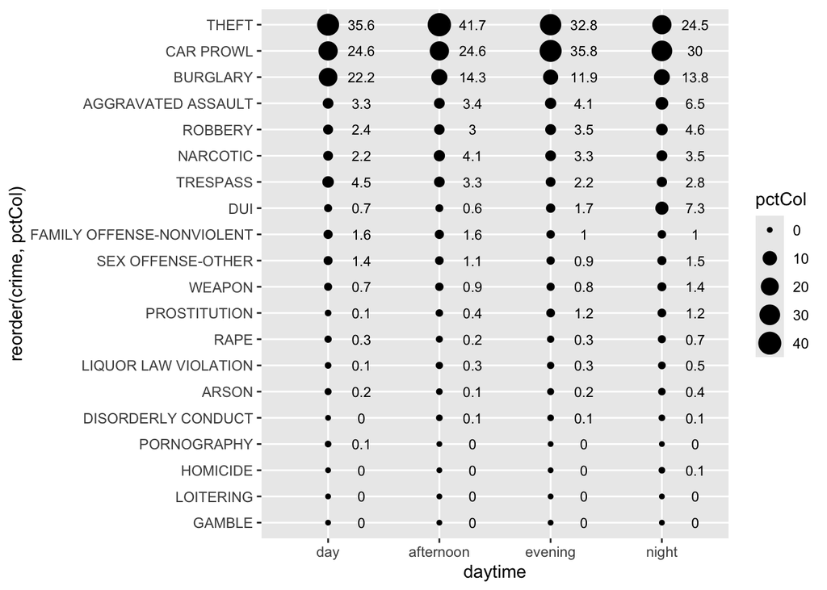

```r
#new base
basePoints = ggplot(CrimeDayDF, aes(x=daytime,y=reorder(crime,pctCol)))
# plot value as point, size by value of percent
tablePlot = basePoints + geom_point(aes(size = pctCol))
# add value of Percent as label
tablePlot = tablePlot + geom_text(aes(label = pctCol),
                                  nudge_x = 0.3,
                                  size=3)
tablePlot
```

Remember points are better for positions, as their area or size differences are difficult to differentiate. Let’s go for a dodged barplot, but with the help of **facets**:

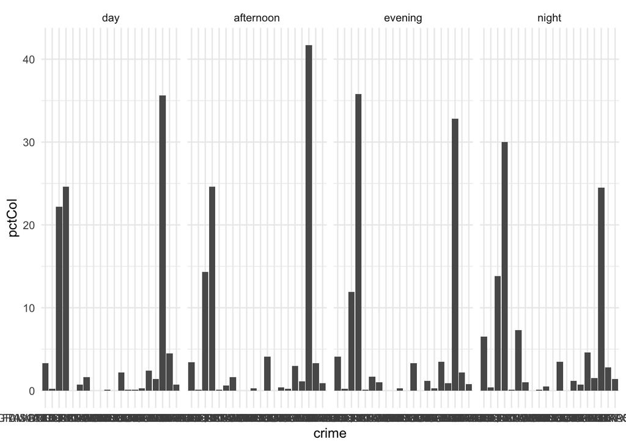

```r
# as usual for barplot (less info than base1)
base4 = ggplot(CrimeDayDF, aes(x = crime, y = pctCol ) )

#the bars
bars4  = base4 + geom_bar( stat = "identity" ) + theme_minimal()

# bar per day time with 'facet'
bars4 = bars4 + facet_grid(~ daytime)

bars4
```

In the previous plot we respected the XY relationship, but this does not look like the crosstable; let’s solve that via flipping:

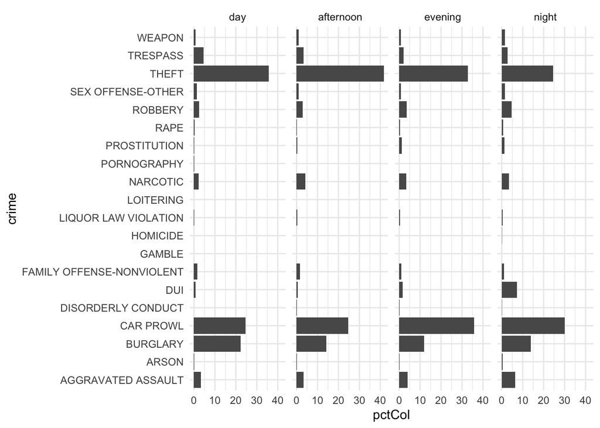

```r
barsFacet = bars4 + facet_grid(~ daytime)  # X
# trick
barsFacet + coord_flip()
```

The type of crime is not ordinal, then we could **reorder** the bars:

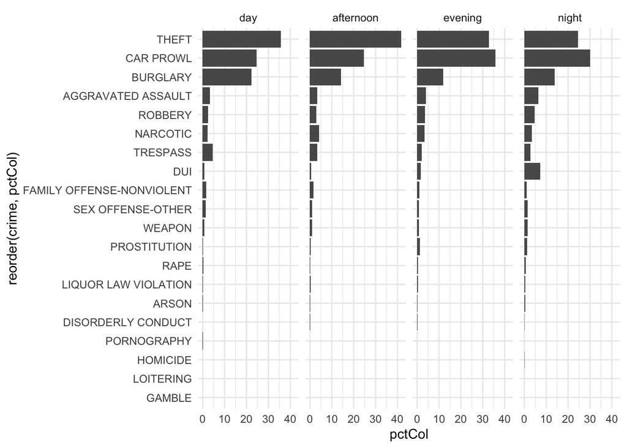

```r
baseRE  = ggplot(CrimeDayDF,
                 aes(x = reorder(crime, pctCol), #here
                     y = pctCol ) ) + theme_minimal()

barsRE = baseRE + geom_bar( stat = "identity" )
barsREFacet = barsRE + facet_grid( ~ daytime)
barsREFacet= barsREFacet + coord_flip()


barsREFacet
```

Let’s annotate:

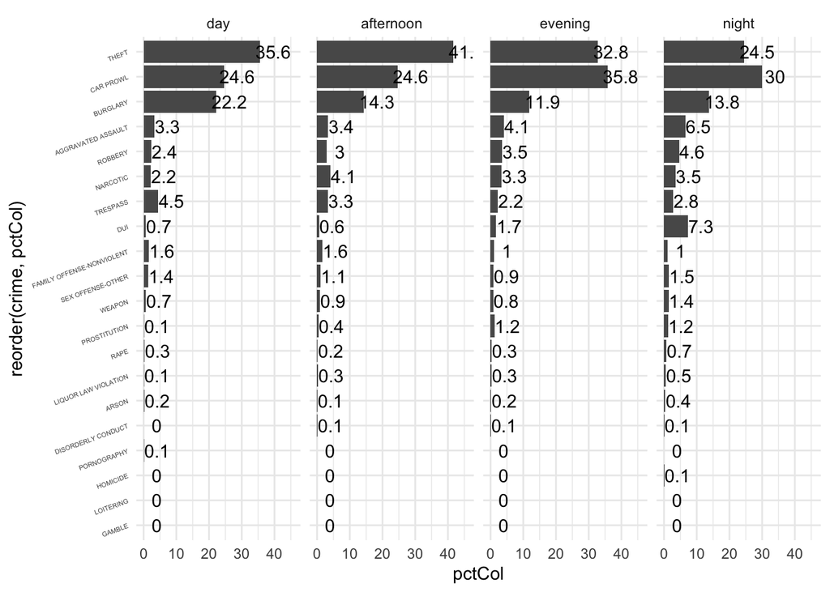

```r
barsREFacet + theme(axis.text.y = element_text(size=4,angle = 20)) +
           geom_text(aes(label=pctCol),
                     nudge_y = 4)
```

Let’s improve the annotation by dropping some texts:

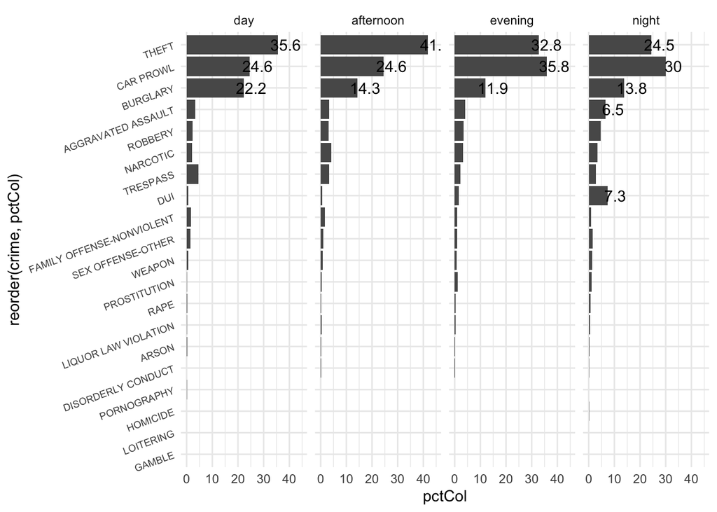

```r
barsREFacet + theme(axis.text.y = element_text(size=7,angle = 20)) +
           geom_text(aes(label=ifelse(pctCol>5,# condition to annotate
                                      pctCol,"")),
                     nudge_y = 3)
```

What about these labels?

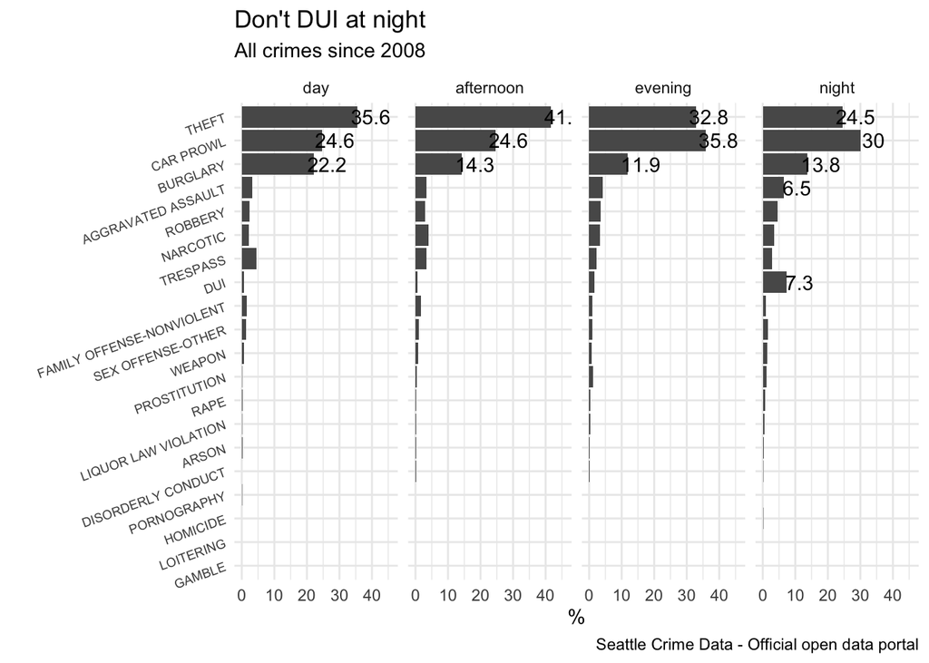

```r
barsREFacet + theme(axis.text.y = element_text(size=7,angle = 20)) +
           geom_text(aes(label=ifelse(pctCol>5,# condition to annotate
                                      pctCol,"")),
                     nudge_y = 4) +
    labs(title= "Don't DUI at night",
         subtitle = "All crimes since 2008",
         caption = "Seattle Crime Data - Official open data portal",
         x="",y="%")
```

Would playing with color gradient make a better plot?

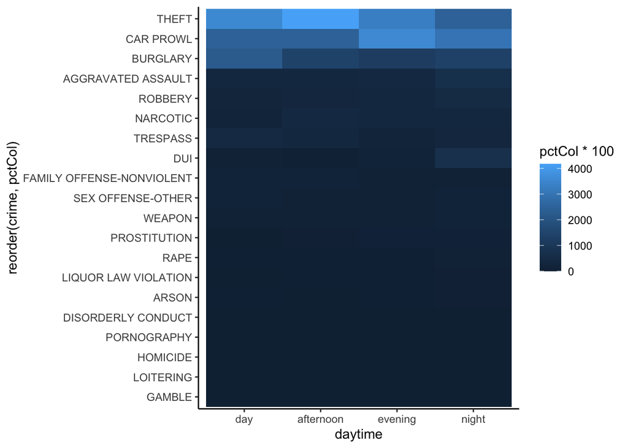

```r
# default

baseHeat  = ggplot(CrimeDayDF, aes(x = daytime,
                               y = reorder(crime, pctCol),
                               fill = pctCol*100)) + theme_classic()
heatDefault = baseHeat +  geom_tile() #here

heatDefault
```

What about some labels and some changes to legend?

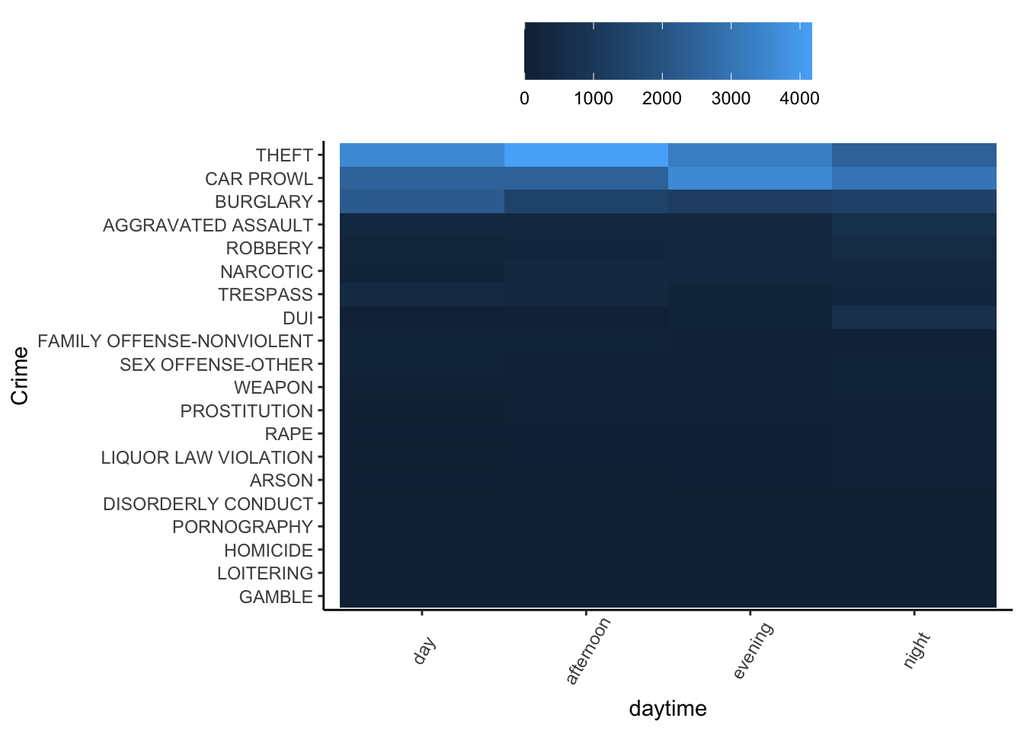

```r
heatDefault= heatDefault + labs(y="Crime", "Time of day")
heatDefault= heatDefault + theme(axis.text.x = element_text(angle = 60,
                                                            vjust = 0.6),
                                 legend.title = element_blank(), #no leg. title
                                 legend.position="top",
                                 legend.direction="horizontal",
                                 legend.key.width=unit(1, "cm"),
                                 legend.key.height=unit(1, "cm"))
heatDefault
```

We should improve color. Let’s try greys:

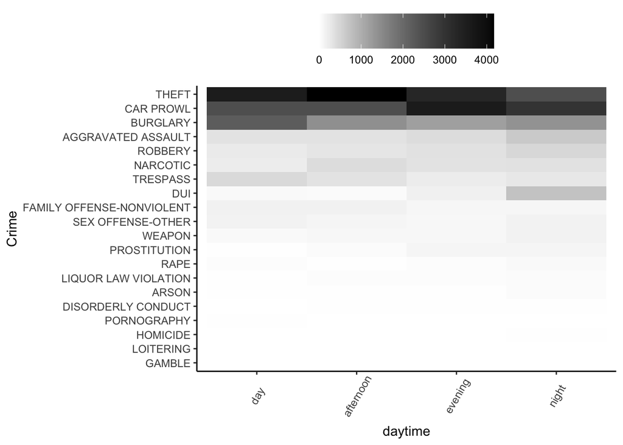

```r
heatGreys = heatDefault +scale_fill_gradient(low = "white",
                                   high = "black")
heatGreys
```

Or a different palette? ([Using colorspace](https://cran.r-project.org/web/packages/colorspace/vignettes/colorspace.html))

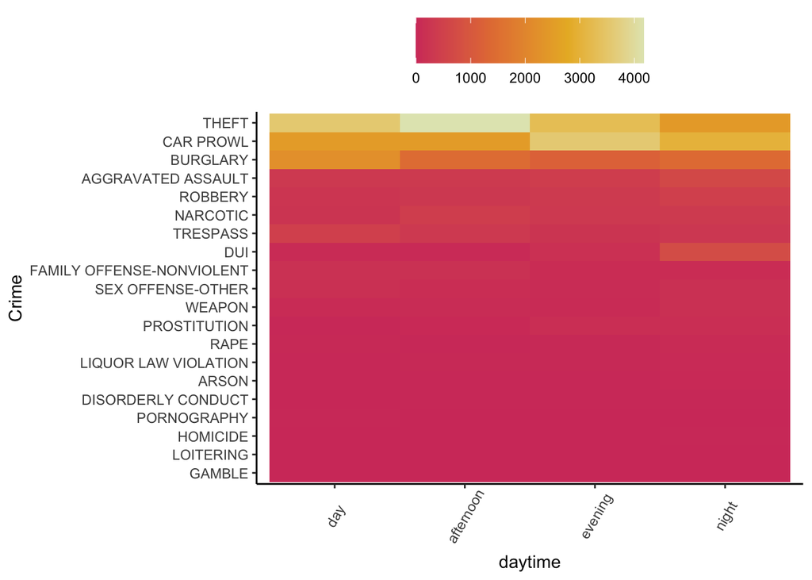

```r
# CHANGING COLORS
heatYllRd = heatDefault +scale_fill_gradientn(colours = colorspace::heat_hcl(4))
heatYllRd
```

And alter the direction of the color with **rev()**:

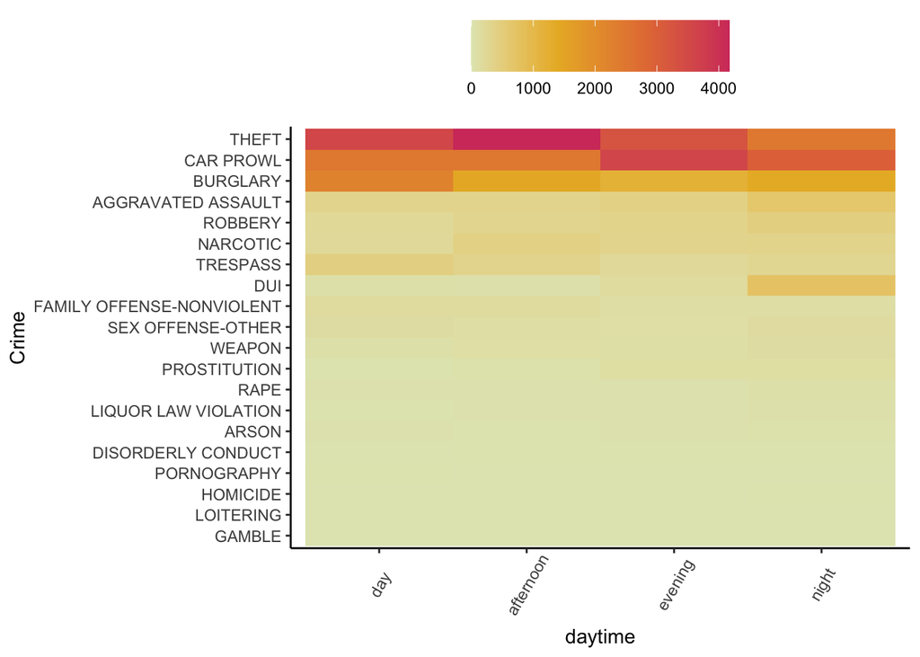

```r
heatYllRd_rev = heatDefault +scale_fill_gradientn(colours = rev(colorspace::heat_hcl(4)))
heatYllRd_rev
```

Is the heatplot better than the facetted barplot? Not really.

Go to table of contents.

## Deliverable II (option 1)

This link has data from this [website](https://www.mass.gov/lists/massachusetts-state-police-arrest-details), which informs about Massachusetts State Police arrest details.

```r
linkMass="https://github.com/DACSS-Visual/tabular_bivar_catcat/raw/refs/heads/main/data/MSP%20DFS%20Arrests%2019-20Q1.xlsx"

#see it
library(rio)
arrests=rio::import(linkMass,which = 1)
head(arrests)
```

```
##      Agency Incident Number Arrest Date Arrest Location
## 1 MSP - DFS 2019-0H2-000018  2019-01-01          DEDHAM
## 2 MSP - DFS 2019-0A1-000026  2019-01-01         METHUEN
## 3 MSP - DFS 2019-0D4-000001  2019-01-01         TAUNTON
## 4 MSP - DFS 2019-0D4-000001  2019-01-01         TAUNTON
## 5 MSP - DFS 2019-0D4-000001  2019-01-01         TAUNTON
## 6 MSP - DFS 2019-0B3-000003  2019-01-01     SPRINGFIELD
##   Arrest Offense by UCR Code Arrest Type Age Sex Race Ethnicity
## 1                        90Z           W  25   M    B         U
## 2                        90Z           M  26   M    H        DR
## 3                        90D           M  28   M    O        CA
## 4                         MV           M  28   M    O        CA
## 5                         MV           M  28   M    O        CA
## 6                        90D           M  28   M    H        MM
```

Use the columns **Arrest Offense by UCR Code** and **Race** to make a visual. The excel file has the data in the first sheet; the second one has the *Arrest codes* (40 codes) and *Race codes* (8 codes).

Go to table of contents.